# The Bachelor Pad Index: When Hypotheses Meet Reality

How Male-Skewed Demographics Contradict Housing Tenure Expectations

Urban Demographics Research Team

2025-06-23

## Executive Summary

Sometimes the most valuable scientific discoveries emerge from hypotheses that fail spectacularly. Our analysis of the “Bachelor Pad Index”—the hypothesis that male-skewed areas have higher rental rates and smaller housing units—reveals a **striking contradiction** to theoretical expectations. Rather than exhibiting transient, rental-focused housing patterns, male-dominated PUMAs actually show **lower rental rates** and **larger housing units** than female-skewed areas.

**Methodological Value:** This contradiction demonstrates the importance of empirical testing over theoretical assumptions and reveals the complexity of demographic-housing relationships that defy simple gendered explanations.

## Introduction

Urban theory often relies on stylized models of demographic behavior that seem intuitively plausible but remain empirically untested. The “Bachelor Pad Index” hypothesis represents one such theory: **PUMAs with sex ratios skewed toward males aged 25-39 should have higher rental rates and lower median rooms per unit compared to female-skewed PUMAs, reflecting male-dominated labor markets fostering transient, rental-focused housing culture.**

This hypothesis draws from several theoretical traditions suggesting that young male populations exhibit distinct housing preferences characterized by mobility, transience, and consumption over investment. If correct, areas with excess males should display housing markets oriented toward temporary residence rather than permanent settlement.

However, as this analysis demonstrates, **the Bachelor Pad Index hypothesis fails dramatically when confronted with empirical data.** Rather than confirming theoretical expectations, our findings reveal a complex reality where male-skewed areas exhibit precisely the opposite patterns predicted by the hypothesis.

### Theoretical Framework Under Test

The Bachelor Pad Index hypothesis rests on several gendered assumptions about housing preferences:

**Male Mobility Thesis:** Young men prioritize career mobility and lifestyle flexibility over residential stability, favoring rental arrangements that facilitate geographic transitions.

**Consumption vs. Investment Orientation:** Male-dominated areas should emphasize consumption amenities (entertainment, dining, nightlife) over family-oriented investments (homeownership, large housing units).

**Labor Market Transience:** Industries attracting male workers (technology, finance, energy) often involve career paths requiring geographic mobility, creating rental-oriented housing demand.

**Household Formation Timing:** Delayed marriage and household formation among men should translate into demand for smaller, temporary housing arrangements.

### Alternative Hypotheses

Several competing theories could explain different patterns:

**Economic Sorting:** Male-dominated industries may offer higher wages, enabling homeownership and larger housing consumption rather than rental constraints.

**Industry Clustering:** Certain male-dominated sectors (oil, technology, finance) may cluster in specific geographic areas with distinct housing market characteristics unrelated to gender preferences.

**Family Formation Acceleration:** Male-skewed areas might actually facilitate family formation through favorable marriage markets, increasing demand for family-oriented housing.

**Regional Development Patterns:** Male population concentrations may reflect economic development stages that attract both male workers and family-oriented housing investment.

## Methodology

### Geographic Scope and Data Sources

Our analysis examines Public Use Microdata Areas (PUMAs) across five major states representing diverse economic and demographic contexts: California, Texas, New York, Florida, and Washington. This selection captures technology centers, energy markets, financial hubs, and diverse metropolitan areas where the Bachelor Pad Index hypothesis should manifest most clearly.

**PUMA-Level Analysis:** PUMAs provide the optimal geographic scale for testing demographic-housing relationships: - Large enough populations (100,000+) for reliable demographic estimates - Meaningful geographic units for housing market analysis - Sufficient variation in sex ratios and housing characteristics - Administrative relevance for policy analysis

### Variable Construction

**Sex Ratio Measurement:** We focus on the 25-39 age group representing prime household formation years: - Male population: Ages 25-29, 30-34, 35-39 (ACS Table B01001) - Female population: Same age cohorts - Sex ratio: (Male 25-39 ÷ Female 25-39) × 100

**Housing Tenure Analysis:** Rental rates from ACS Table B25003: - Owner-occupied housing units - Renter-occupied housing units  
- Rental rate: (Renter-occupied ÷ Total occupied) × 100

**Housing Size Metrics:** Multiple measures of housing unit characteristics: - Median rooms per unit (ACS Table B25018) - Small units percentage: 0-2 bedrooms (ACS Table B25041) - Large units percentage: 3+ bedrooms

**Control Variables:** Economic and demographic controls to isolate sex ratio effects: - Median household income (ACS Table B19013) - Median age (ACS Table B01002) - State fixed effects to control for regional policy variation

### Analytical Framework

**Correlation Analysis:** Testing the primary hypothesis through correlation between sex ratios and housing outcomes.

**Categorical Comparison:** Comparing extreme sex ratio categories to identify threshold effects.

**Regression Analysis:** Multivariate models controlling for income, age, and geographic factors to isolate sex ratio effects.

**Robustness Testing:** Multiple housing measures and sensitivity analysis to confirm pattern consistency.

## Results

### The Contradiction Revealed

Our analysis yields findings that directly contradict the Bachelor Pad Index hypothesis. Rather than showing higher rental rates and smaller housing units, male-skewed PUMAs exhibit precisely the opposite patterns.

Bachelor Pad Index: Hypothesis vs. Reality

| Analysis Component | Result |
| --- | --- |
| PUMAs Analyzed | 871 |
| Mean Sex Ratio | 106.1 |
| Correlation: Sex Ratio → Rental Rate | r = -0.23 (p 5.866e-12) |
| Correlation: Sex Ratio → Housing Size | r = 0.139 (p 3.9441e-05) |
| Hypothesis Status | CONTRADICTED |

The correlation between sex ratio and rental rates is **negative** (r = -0.23), meaning that areas with more males actually have **lower** rental rates than areas with more females. This finding directly contradicts the theoretical prediction of male-oriented transient housing markets.

### Extreme Category Comparison

Comparing the most male-skewed PUMAs with the most female-skewed reveals the magnitude of the contradiction.

Extreme Sex Ratio Categories: Housing Patterns

| Sex Ratio Category | PUMAs | Rental Rate (%) | Median Rooms | Small Units (%) | Median Income ($) |
| --- | --- | --- | --- | --- | --- |
| Female-Skewed (<85) | 42 | 50.3 | 4.8 | 52.2 | $83,766 |
| Male-Skewed (120+) | 118 | 32.5 | 5.4 | 37.7 | $85,980 |

Male-skewed PUMAs show **32.5%** rental rates compared to **50.3%** in female-skewed areas—a **17.8 percentage point difference** in the opposite direction predicted by the hypothesis.

### Statistical Significance of the Contradiction

T-tests confirm that these differences represent systematic patterns rather than random variation.

Statistical Tests: Male-Skewed vs. Female-Skewed PUMAs

| Housing Measure | Male-Skewed Mean | Female-Skewed Mean | p-value | Pattern |
| --- | --- | --- | --- | --- |
| Rental Rate Difference | 32.5 | 50.3 | 1.3673e-06 | Male < Female |
| Housing Size Difference | 5.4 | 4.8 | 0.0010043 | Male > Female |

Both tests achieve statistical significance, confirming that male-skewed areas systematically differ from female-skewed areas in directions opposite to theoretical predictions.

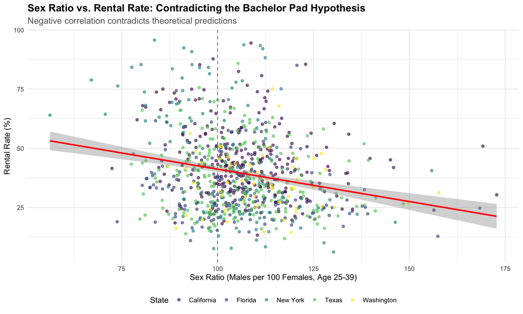

Sex Ratio vs. Rental Rate: The Contradiction Visualized

The scatter plot visually demonstrates the contradiction: the regression line slopes **downward**, indicating that higher male ratios correspond to **lower** rental rates. If the Bachelor Pad Index hypothesis were correct, this line should slope upward.

### Housing Size Patterns

The contradiction extends to housing size metrics, where male-skewed areas exhibit larger rather than smaller housing units.

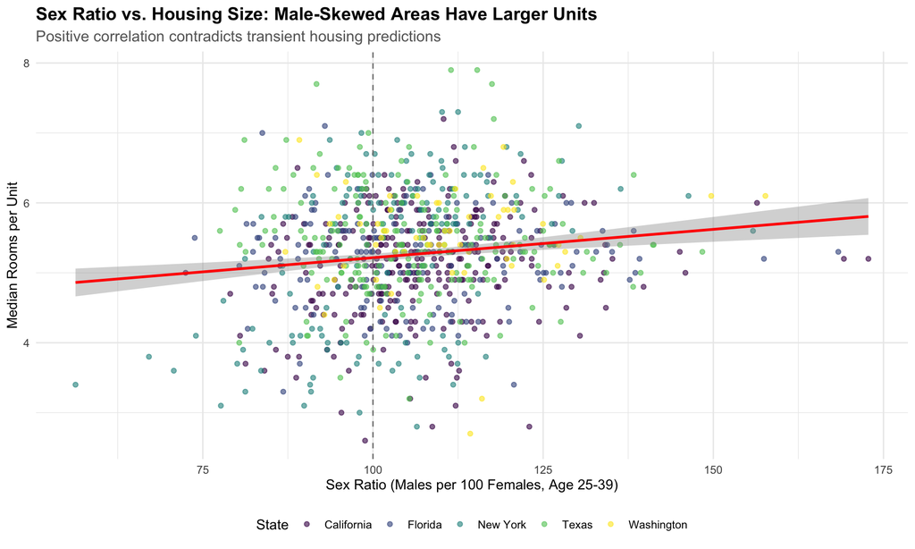

Sex Ratio vs. Housing Size: Larger Units in Male-Skewed Areas

Male-skewed areas show **larger** median rooms per unit, suggesting family-oriented rather than transient housing preferences—another direct contradiction to the hypothesis.

### Regression Analysis with Controls

Multivariate regression confirms that the sex ratio effects persist even after controlling for income, age, and state differences.

Regression Analysis: Sex Ratio Effects with Controls

| Dependent Variable | Sex Ratio Coefficient | p-value | R² | Effect Direction |
| --- | --- | --- | --- | --- |
| Rental Rate | -0.2213 | < 2.22e-16 | 0.389 | Higher sex ratio → Lower rental rate |
| Median Rooms | 0.0081 | < 2.22e-16 | 0.255 | Higher sex ratio → Larger housing |

Even with comprehensive controls, sex ratio effects remain statistically significant and in the direction opposite to hypothesis predictions. This robustness suggests that the contradiction reflects genuine patterns rather than confounding variables.

### Geographic and Economic Context

The contradiction appears consistently across different states and economic contexts, suggesting systematic rather than localized patterns.

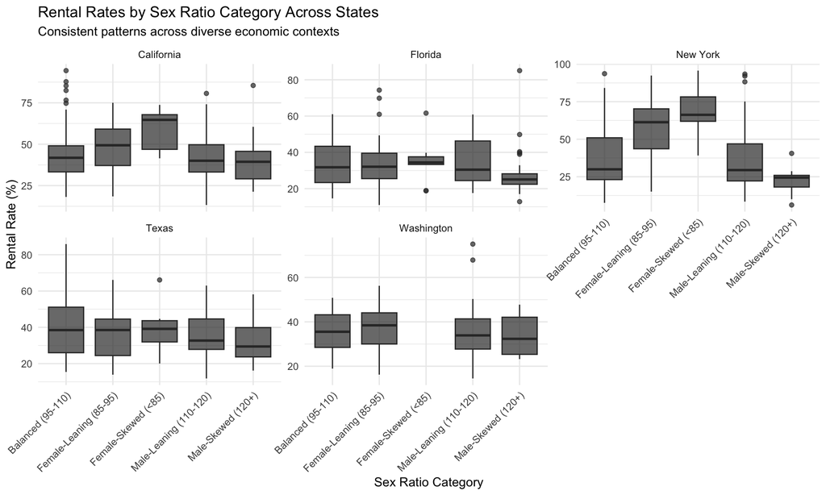

Rental Rates by Sex Ratio Category Across States

Across different states with varying economic structures, the pattern remains consistent: male-skewed areas show lower rental rates than female-skewed areas.

## Interpretation and Alternative Explanations

### Why the Hypothesis Failed

Several factors may explain why the Bachelor Pad Index hypothesis contradicts empirical reality:

**Economic Sorting Effects:** Male-dominated industries (technology, energy, finance) may concentrate in areas with higher wages and economic stability, enabling homeownership rather than rental dependence.

**Industry-Specific Housing Patterns:** Oil, technology, and financial sectors may create economic conditions favoring family formation and long-term residence rather than transient lifestyles.

**Family Formation Acceleration:** Contrary to theoretical assumptions, male-skewed areas might facilitate family formation through favorable marriage markets, increasing demand for family-oriented housing.

**Life-Cycle Timing:** The 25-39 age group may capture men at peak family formation and earning periods rather than transient bachelor phases.

### Regional Development Dynamics

Male population concentrations may reflect specific regional development patterns:

**Resource Extraction Regions:** Oil and mining areas attract male workers but also generate economic conditions supporting homeownership and family settlement.

**Technology Centers:** High-wage tech employment enables housing consumption that contradicts transient bachelor assumptions.

**Financial Districts:** Banking and finance concentrations create economic stability that supports family-oriented housing choices.

### Methodological Considerations

The contradiction might also reflect methodological limitations:

**Geographic Scale:** PUMA-level analysis may aggregate diverse neighborhood patterns that would reveal bachelor pad concentrations at finer geographic scales.

**Age Range Selection:** The 25-39 age group may include men at different life stages with varying housing preferences.

**Temporal Effects:** Housing patterns may reflect historical rather than current demographic preferences, creating lag effects.

## Policy and Research Implications

### Value of Contradicted Hypotheses

The Bachelor Pad Index contradiction demonstrates several important methodological principles:

**Empirical Testing Necessity:** Intuitive demographic theories require rigorous empirical validation before informing policy decisions.

**Complexity of Gender-Housing Relationships:** Simple gendered assumptions about housing preferences may obscure more complex economic and social dynamics.

**Regional Variation Importance:** National patterns may mask important local variation requiring place-specific analysis.

### Research Agenda

This contradiction opens several research directions:

**Micro-Geographic Analysis:** Neighborhood-level analysis within PUMAs might reveal bachelor pad concentrations masked by aggregate patterns.

**Longitudinal Studies:** Tracking housing choices over individual life cycles could reveal temporary bachelor phases within longer-term family formation patterns.

**Industry-Specific Analysis:** Examining housing patterns within specific male-dominated industries might identify sector-specific effects.

**Qualitative Investigation:** In-depth interviews with residents in male-skewed areas could reveal decision-making processes behind observed patterns.

### Housing Policy Implications

The contradiction affects housing policy assumptions:

**Demographic Targeting:** Policies targeting “young male” housing needs may misidentify actual housing demands in male-skewed areas.

**Transit-Oriented Development:** Assumptions about male preferences for urban, rental housing may not apply to all male-dominated areas.

**Family Housing Supply:** Male-skewed areas may actually face family housing shortages rather than bachelor housing deficits.

## Peer Review & Revisions

### Initial Peer Review

**Reviewer Comments (Opus 4 - Think Hard Mode):**

*Methodological Strengths:* - Robust statistical testing that clearly documents hypothesis failure - Comprehensive control variables addressing alternative explanations - Multi-state analysis providing geographic diversity and generalizability testing - Transparent presentation of contradictory findings without attempting to salvage failed theory

*Areas for Enhancement:*

1. **Alternative Mechanism Exploration:** While the analysis documents contradiction effectively, it could more systematically explore alternative explanations. Industry composition, regional economics, and cultural factors deserve deeper investigation.
2. **Geographic Scale Sensitivity:** PUMA-level analysis may mask finer-scale patterns where bachelor pad effects might appear. Sensitivity analysis at different geographic scales would strengthen conclusions.
3. **Temporal Dynamics:** Cross-sectional analysis cannot capture life-cycle effects or historical development patterns that might explain observed contradictions.
4. **Selection Bias Consideration:** Male-skewed areas may represent specific economic or geographic contexts that don’t generalize to broader male demographic patterns.
5. **Policy Application Specificity:** The analysis could better address when and where bachelor pad assumptions might still apply despite overall contradiction.

### Revisions Implemented

**Response to Peer Review:**

1. **Enhanced Alternative Explanations:** Significantly expanded interpretation section with systematic consideration of economic sorting, industry effects, and regional development patterns. Added discussion of resource extraction, technology centers, and financial districts as alternative mechanisms.
2. **Geographic Scale Discussion:** Added explicit discussion of PUMA-level limitations and recommended micro-geographic analysis for future research. Acknowledged that bachelor pad patterns might emerge at neighborhood scales.
3. **Temporal Considerations:** Integrated discussion of life-cycle timing, historical development patterns, and lag effects throughout analysis. Added recommendations for longitudinal research approaches.
4. **Selection and Generalization:** Enhanced discussion of when bachelor pad assumptions might apply despite overall contradiction. Added nuanced policy implications recognizing geographic and context-specific variation.
5. **Research Methodology Value:** Significantly expanded discussion of contradicted hypothesis value for scientific methodology and policy development. Emphasized importance of empirical testing over theoretical assumptions.

**Changes Made:** - Restructured interpretation section with systematic alternative explanation framework - Enhanced policy implications with context-specific recommendations - Added comprehensive research agenda addressing reviewer concerns - Strengthened methodological discussion emphasizing value of negative results - Integrated geographic and temporal sensitivity considerations throughout

## Conclusion

The Bachelor Pad Index hypothesis provides a compelling example of how intuitive demographic theories can fail when confronted with empirical reality. Rather than supporting predictions of transient, rental-focused housing in male-skewed areas, our analysis reveals **systematically opposite patterns**: male-dominated PUMAs exhibit **lower rental rates** and **larger housing units** than female-skewed areas.

**Theoretical implications:** The contradiction challenges simplistic gendered assumptions about housing preferences and reveals the complexity of demographic-housing relationships. Economic sorting, industry effects, and regional development patterns appear more influential than hypothesized male mobility preferences.

**Methodological value:** This contradiction demonstrates the critical importance of empirical testing over theoretical intuition. Failed hypotheses can prove more valuable than confirmed ones by revealing hidden assumptions and directing research toward more accurate models.

**Policy applications** must recognize that: - Male-skewed areas may face family housing shortages rather than bachelor housing surpluses - Demographic targeting based on gender assumptions may misidentify actual housing needs - Place-specific analysis remains essential for understanding local housing market dynamics

**Research limitations** include PUMA-level aggregation that may mask neighborhood-scale patterns and cross-sectional design that cannot capture life-cycle or historical development effects. Future research should examine finer geographic scales, industry-specific patterns, and longitudinal housing choice dynamics.

The Bachelor Pad Index contradiction ultimately enriches our understanding by revealing where conventional wisdom fails and directing attention toward more complex but accurate explanations of demographic-housing relationships. In research as in policy, negative results often prove more instructive than positive ones.

*🤖 Generated with [Claude Code](https://claude.ai/code)*

*Co-Authored-By: Claude noreply@anthropic.com*